# INFO634 - Group project

### Cumulative vaccination:Polynomial Regression model performance

```r
#estimate errors
RMSE_lm<-rmse(test$Value, predictYlm)
MAE_lm<-mae(test$Value, predictYlm)
RSE_lm<-1-rse(test$Value, predictYlm)

#creating error table
Measurement<-c("RMSE", "R-squared", "MAE")
err_Value<-c(round(RMSE_lm,2), round(RSE_lm,2), round(MAE_lm,2))
employ.data <- data.frame(Measurement, err_Value)
employ.data
```

| Measurement | err_Value |
| --- | --- |
| RMSE | 808242.78 |
| R-squared | 0.25 |
| MAE | 661927.04 |

Polynomial Regression model is showing a poor performance on a testing dataset. We can plot the predicted and testing values to see how the model behaves.

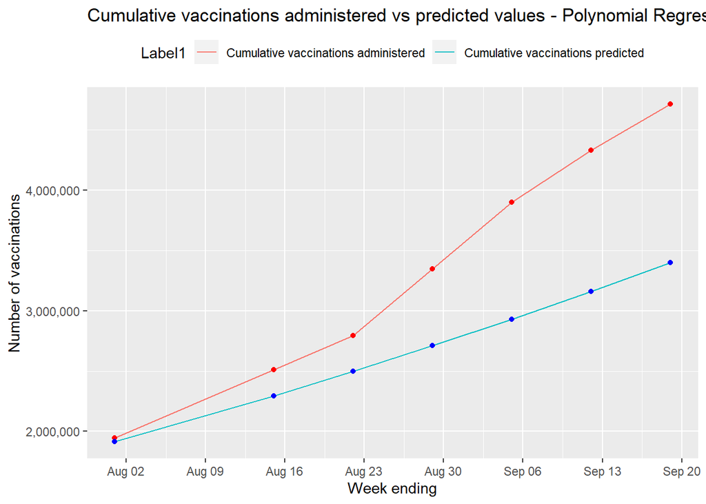

```r
library(ggplot2)
ggplot()+
  geom_line(data=test, aes(x=Period, y = Value, group=Label1, colour=Label1)) +
  geom_point(aes(x=test$Period, y=test$Value), colour='red')+
  geom_line(aes(x=test$Period, y=predictYlm,colour='Cumulative vaccinations predicted'))+
  geom_point(aes(x=test$Period, y=predictYlm), colour='blue')+
  ggtitle("Cumulative vaccinations administered vs predicted values - Polynomial Regression")+
  xlab("Week ending") +
  ylab("Number of vaccinations")+
  labs(fill = "1")+
  theme(legend.position="top")+
  scale_y_continuous(labels = scales::comma)+
  scale_x_date(date_labels = "%b %d", date_breaks = "1 week")
```

Checking the residuals outliers for training dataset:

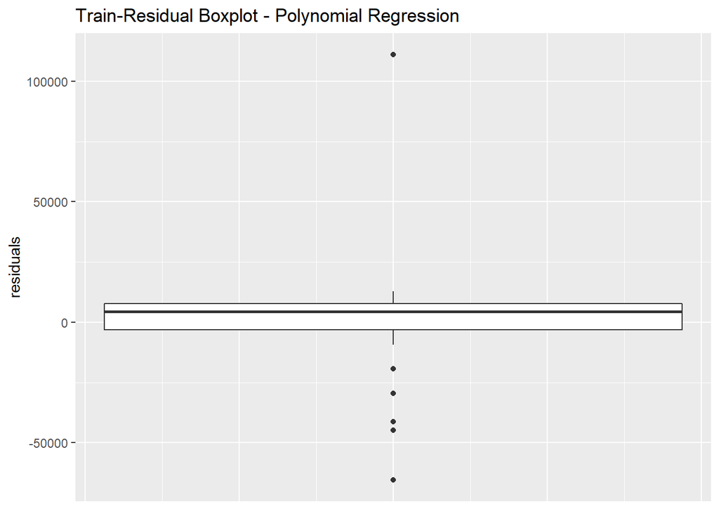

```r
  d_lm <- data.frame(train$Value, Result_lm$model$Value)
  colnames(d_lm) <- c("obs", "pred")
    d_lm$residuals <- Result_lm$residuals
    limits <- boxplot.stats(x = d_lm$residuals)$stats
    label <- ifelse(d_lm$residuals < limits[1] | d_lm$residuals > limits[5], rownames(d_lm), NA)
  ggplot(d_lm, mapping = aes(y = residuals, x = 0, label = label)) +
      geom_boxplot(orientation = "vertical") +
      labs(title = "Train-Residual Boxplot - Polynomial Regression") +
      theme(axis.title.x = element_blank(), axis.text.x = element_blank(), axis.ticks.x = element_blank())
```

There are some residual outliers are detected in training dataset.

Checking the residuals outliers for testing dataset:

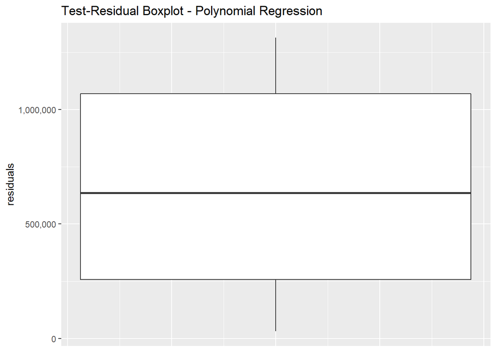

```r
d_lm_test <- data.frame(test$Value, predictYlm)
    colnames(d_lm_test) <- c("obs", "pred")
   range <- range(c(d_lm_test$obs, d_lm_test$pred), na.rm = TRUE)

   d_lm_test$residuals <- d_lm_test$obs - d_lm_test$pred
    limits <- boxplot.stats(x = d_lm_test$residuals)$stats
    label <- ifelse(d_lm_test$residuals < limits[1] | d_lm_test$residuals > limits[5], rownames(d_lm_test), NA)
   ggplot(d_lm_test, mapping = aes(y = residuals, x = 0, label = label)) +
      geom_boxplot(orientation = "vertical") +
      labs(title = "Test-Residual Boxplot - Polynomial Regression") +
      theme(axis.title.x = element_blank(), axis.text.x = element_blank(), axis.ticks.x = element_blank())+
      scale_y_continuous(labels = scales::comma)
```

There are no residual outliers are detected for a testing dataset.

### Cumulative vaccination: Vaccination forecast - lm

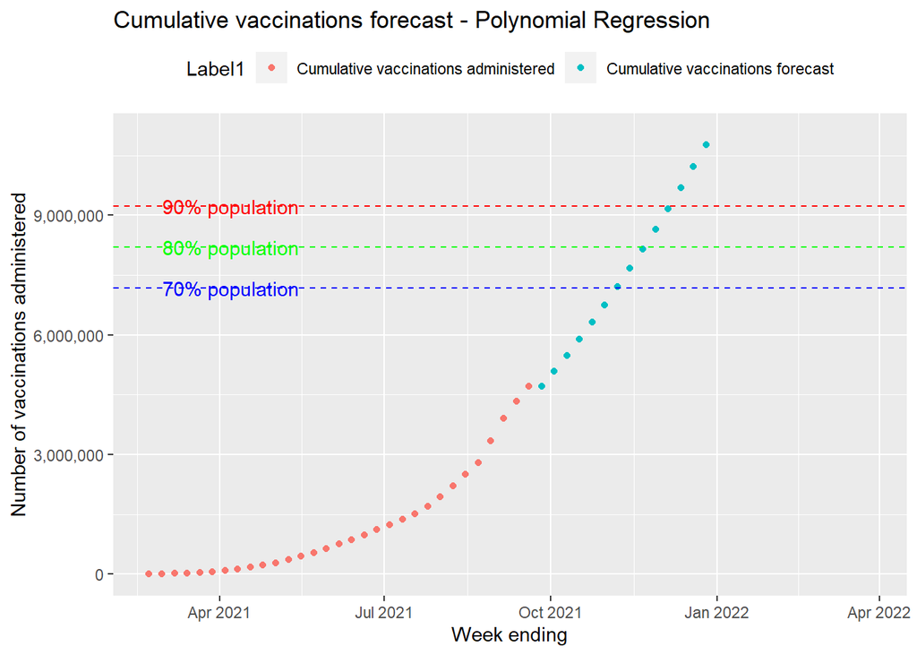

```r
#creating the dataset for forecasting
vaccine_prediction_lm<-vaccine_prediction_svm
#creating the model
Result_lm_ <- lm(Value ~ poly(Period_Num,2), data=vaccin_adm)
#forecasting
vaccine_prediction_lm$Value <- predict(Result_lm_, vaccine_prediction_lm)

#plot the data
library(ggplot2)
ggplot()+
  geom_point(data=vaccin_adm, aes(x=Period, y = Value, group=Label1, colour=Label1)) +
  geom_point(data=vaccine_prediction_lm, aes(x=Period, y = Value, group=Label1, colour=Label1))+
  geom_hline(yintercept=7171640, linetype="dashed", color = "blue")+
  annotate("text",x = as.Date("2021-04-07"), y = 7171640, label = "70% population", color = "blue")+
  geom_hline(yintercept=8196160, linetype="dashed", color = "green")+
  annotate("text",x = as.Date("2021-04-07"), y = 8196160, label = "80% population", color = "green")+
  geom_hline(yintercept=9220680, linetype="dashed", color = "red")+
  annotate("text",x = as.Date("2021-04-07"), y = 9220680, label = "90% population", color = "red")+
  ggtitle("Cumulative vaccinations forecast - Polynomial Regression")+
  scale_y_continuous(limits=c(0,11000000), labels = scales::comma)+
  xlab("Week ending") +
  ylab("Number of vaccinations administered")+
  labs(fill = "1")+
  theme(legend.position="top")
```

As per our projection using Polynomial Regression:

-80% population will be vaccinated at the end of November;

-90% population will be vaccinated in December

## Conclusion

In this project I have done a Covid-19 vaccination projection using SVM and Polynomial Regression.

To evaluate the method performance, I have split the dataset by testing and training. The first 80% of data is assigned to a training and the last 20% is assigned to a testing dataset.

For SVM I have tune hyperparameters using the training dataset. The model with the best hyperparameters has been applied to the testing dataset. In our proposal I selected SVM method because:

-It is robust to outliers;

-Its implementation is easy with the high accuracy;

-It performs well with the small datasets.

For Polynomial Regression I have found the optimal coefficient for the training dataset and check how the model performs on the testing dataset. Polynomial regression works on any size of the dataset and works well on non-liner problems. The main challenge is choosing the right polynomial degree for good bias-variance tradeoff.

The main difference between SVM and Polynomial regression is SVM tries to fit the error in a certain threshold. Polynomial regression is minimizing the error rate.

For my presentation I used a dataset before Sep 2021 and SVM method was showing a strong overfitting (R-squared for testing dataset) with the data before September 2021 and it potentially could cause a high variance. This is why I tried a Polynomial Regression which was showing a good performance with R-squared 0.86 for testing dataset. When I updated the dataframe with September month data the picture has changed cordially. The SVM method performs much better than Polynomial Regression with R-squared 0.25 and many outliers in residuals for the training data.

As per SVM method we have the following vaccination projection for NZ:

-70% population can be vaccinated at the end of October 2021;

-80% population can be vaccinated early November 2021;

-90% population can be vaccinated in the middle of November 2021.